# R Bootcamp 2019

2019-08-22 02:33:11

## R Radio (We R Family)

[video not shown]

## R Radio (We R the Champions)

[video not shown]

## R Radio (You R So Beautiful)

[video not shown]

## Acknowledgments

- [Department of Human Development & Family Studies (HDFS)](https://hhd.psu.edu/hdfs)
- [Department of Psychology](https://psych.la.psu.edu)
- [Social, Life, & Engineering Sciences Imaging Center (SLEIC)](https://www.imaging.psu.edu)
- [Child Study Center’s Open Data and Developmental Science (ODDS) initiative](http://csc.la.psu.edu/research/collaborative-research-initiatives)
- [Teaching & Learning with Technology (TLT)](https://tlt.psu.edu/)

## Agenda

- Welcome and introductions
- Who R you?
- Housekeeping
- Schedule
- Aspirations & Philosophy
- The stoRy of R

## Welcome and introductions

- Mimi Brinberg
- Sy-Miin Chow
- Rick Gilmore
- Michael Hallquist
- Nilam Ram

## Welcome and introductions

- Dan Albohn
- Mimi Brinberg
- Kayla Brown
- Meng Chen
- Nate Hall
- Rebecca Janis
- Linying Ji
- Jungmin Li
- Yanling Li
- Jonathan Park
- Yiming Qian
- Alicia Vallorani
- Holly Zaharchuk

## Who R You?

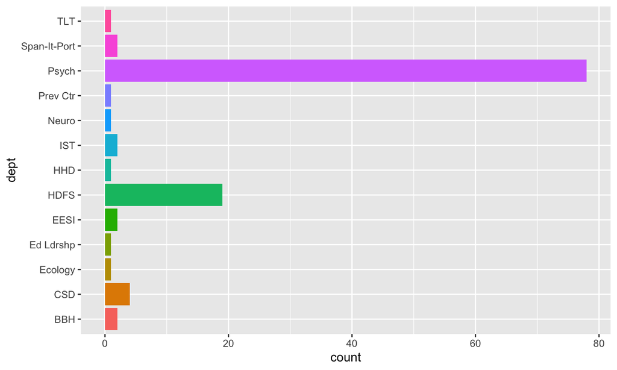

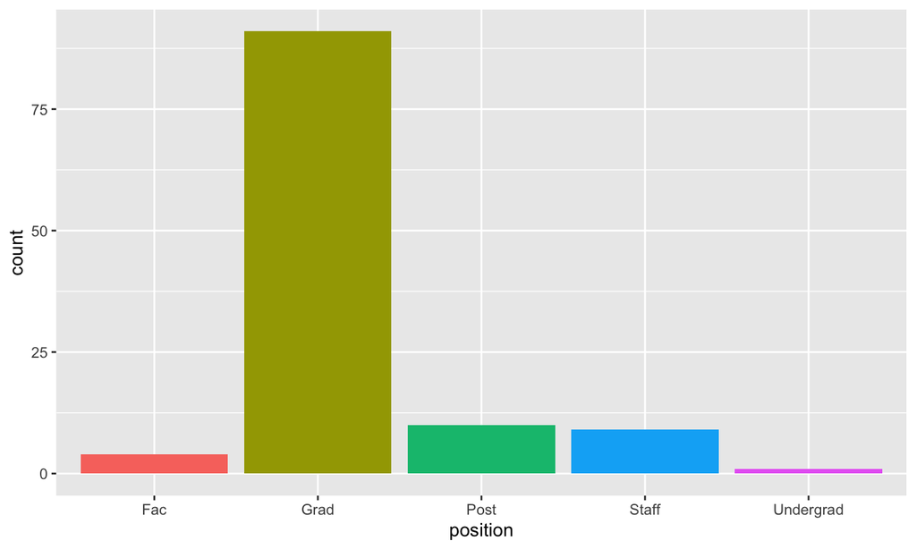

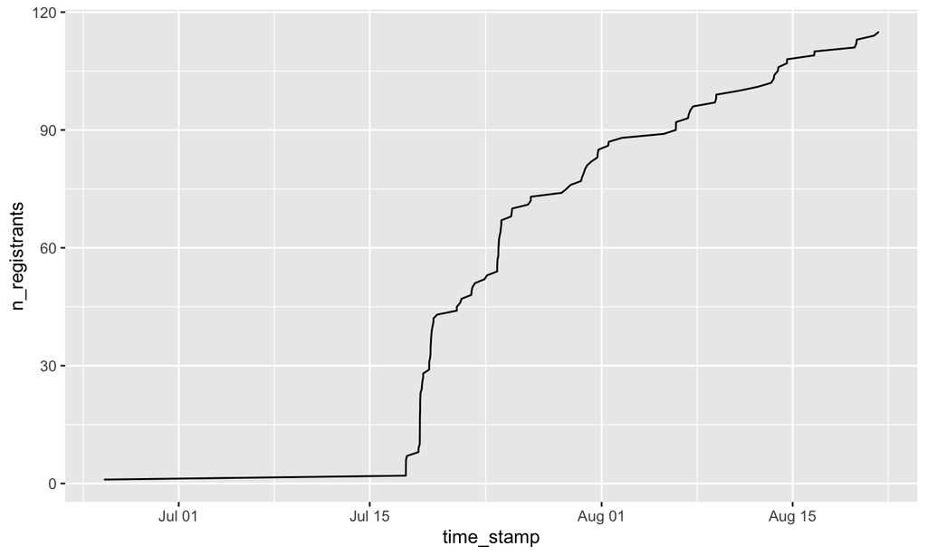

## Housekeeping

- Bootcamp materials on GitHub: https://github.com/psu-psychology/r-bootcamp-2019
- Bootcamp website: http://psu-psychology.github.io/r-bootcamp-2019
- **Survey**: Please complete this anonymous (and light-hearted) [survey](https://docs.google.com/forms/d/1NFNWAfCckA8Vxlb6LDa4RUqn7OB3FcgJTjXdRC8_JBs/edit) *before the end of the day tomorrow (Thursday)*.
- **Sessions are being video recorded**. 2017 is on [Databrary](http://doi.org/10.17910/B7.473).

## Housekeeping continued

- Toilets on this floor near elevators
- Two stairway entrances/exits
- No food or drink (except water bottles with lids) in these rooms
- Use Zoom to follow along, but do **NOT** unmute sound unless you have headphones

## Schedule

- **Day 1** (Wednesday, August 21, 2019)
- **Day 2** (Thursday, August 22, 2019)
- **Day 3** (Friday, August 23, 2019)

## Day 1 (Wed 8/21) Schedule

08:30 am • Breakfast in Moore lobby

| Plenary, 210 Keller |
| --- |
| 09:00 am • Welcome, introductions, & housekeeping |
| 09:15 am • Why We R Here |
| 09:45 am • Break |

## Day 1 (Wed 8/21) Schedule

| Slow-R Track, 210 Keller |  | Fast-R Track, 211 Keller |
| --- | --- | --- |
| 10:00 - 11:00am • RStudio, R console, object classes & data types (Rick Gilmore) |  | 10:00 - 11:00 am • Multilevel models, moderation, & probing interactions in `lme4` (Mimi Brinberg) |
| 11:00 am - 12:00 pm • Hands on with RStudio |  | 11:00 am - 12:00 pm • Hands on with multilevel models |

## Day 2 (Thu 8/22) Schedule

08:30 am • Breakfast in Moore lobby

| Slow-R Track, 210 Keller |  | Fast-R Track, 211 Keller |
| --- | --- | --- |
| 09:00 - 09:45 am • Data indexing and subsetting (Rick Gilmore) |  | 09:00 - 10:00 am • Introduction to structural equation modeling (SEM) in `lavaan` (Michael Hallquist) |
| 09:45 - 10:30 am • Hands on practice |  | 10:00 am - 10:30 am • Hands on with `lavaan` |
| 10:30 - 10:45 am • Break |  | 10:30 - 10:45 am • Break |
| 10:45 - 11:30 am • Packages, scripts, & functions (Rick Gilmore) |  | 10:45 - 11:45 am • Dynamical systems analysis using `dynr` (Sy-Miin Chow) |
| 11:30 am - 12:15 pm • Hands on practice |  | 11:45 am - 12:15 pm • Hands-on practice/demo with `dynr` |

## Day 3 (Fri 8/23) Schedule

08:30 am • Breakfast in Moore lobby

## Aspirations & Philosophy

- You **can** learn to program
- You **should** learn to program
- R is a good language for learning programming

[figure not shown]

## The storRy of R

[figure not shown]

## The storRy of *our* R

- What is R?
  - A programming language, written by and for statisticians & data scientists
- Why is it called R?
  - TLDR: it’s the free, open-source version of a commercial program called S developed in the 1970s at Bell Labs
  - Bell Labs is also the home of C, and the Unix operating system

## The storRy of R

- Features of R
  - Written in C, Fortran, and R
  - 20th most [popular programming language](https://www.tiobe.com/tiobe-index/)
  - Base R (now 3.6.1) + thousands of packages
  - Object-oriented

## Using R

- In the cloud from your browser
  - https://lxclusterapps.tlt.psu.edu:8787

## Your turn

- Why do you want to learn R?
- If you know some R, what else do you want to learn?
- Complete the survey

[figure not shown]

- Testimonials?

## Next steps

- Have fun, ask questions
- Slow R (stay here in 210 Keller)
- Fast R (go next door to 211 Keller)
- Coffee in Moore lobby